# Introducción modelos pronóstico

En el presente capítulo se aplica la metodología Holt-Winter y de suavizamiento a las series de tiempo estudiadas en el documento. Con los *datasets* procesados en los capítulos 2 [Conjunto de datos] y 3 [Preprocesamiento y visualización], se procede con los análisis en mención.

## Tendencias y ciclos

Se seleccionan las series con años seguidos con datos, por lo que se analizarán la precipitación total diaria de Bogotá entre los años 2018 y 2019 y la temperatura máxima diaria de Medellín entre 2022 y 2023.

```r
# Serie xts Precipitación total diaria Bogotá 2018-2019
BOG_rain_2018_2019 <- df_rain_ts["2018/2019", "BOG"]
str(BOG_rain_2018_2019)
```

```
## An xts object on 2018-01-01 / 2019-12-31 containing:
##   Data:    double [730, 1]
##   Columns: BOG
##   Index:   Date [730] (TZ: "UTC")
```

```r
class(BOG_rain_2018_2019)
```

```
## [1] "xts" "zoo"
```

```r
start(BOG_rain_2018_2019)
```

```
## [1] "2018-01-01"
```

```r
end(BOG_rain_2018_2019)
```

```
## [1] "2019-12-31"
```

```r
frequency(BOG_rain_2018_2019)
```

```
## [1] 1
```

```r
colSums(is.na(BOG_rain_2018_2019))
```

```
## BOG
##   0
```

```r
# Serie ts Precipitación total diaria Bogotá 2018-2019
BOG_rain_2018_2019_ts <- as.ts(BOG_rain_2018_2019)
class(BOG_rain_2018_2019_ts)
```

```
## [1] "ts"
```

```r
str(BOG_rain_2018_2019_ts)
```

```
##  Time-Series [1:730] from 1 to 730: 13.8 0.1 2.2 0 17.1 0.3 0.1 0 5.6 8.8 ...
```

```r
summary(BOG_rain_2018_2019_ts)
```

```
##    Min. 1st Qu.  Median    Mean 3rd Qu.    Max.
##   0.000   0.000   0.000   1.683   0.975  32.400
```

```r
# Serie xts Temperatura máxima diaria Medellín 2022-2023
MED_temp_2022_2023 <- df_temp_max_ts["2022/2023", "MED"]
str(MED_temp_2022_2023)
```

```
## An xts object on 2022-01-01 / 2023-12-31 containing:
##   Data:    double [730, 1]
##   Columns: MED
##   Index:   Date [730] (TZ: "UTC")
```

```r
class(MED_temp_2022_2023)
```

```
## [1] "xts" "zoo"
```

```r
start(MED_temp_2022_2023)
```

```
## [1] "2022-01-01"
```

```r
end(MED_temp_2022_2023)
```

```
## [1] "2023-12-31"
```

```r
frequency(MED_temp_2022_2023)
```

```
## [1] 1
```

```r
colSums(is.na(MED_temp_2022_2023))
```

```
## MED
##   0
```

```r
# Serie ts Temperatura máxima diaria Medellín 2022-2023
MED_temp_2022_2023_ts <- as.ts(MED_temp_2022_2023)
class(MED_temp_2022_2023_ts)
```

```
## [1] "ts"
```

```r
str(MED_temp_2022_2023_ts)
```

```
##  Time-Series [1:730] from 1 to 730: 27.4 26.4 27.8 28 28.2 26 25 26.8 27.4 24.6 ...
```

```r
summary(MED_temp_2022_2023_ts)
```

```
##    Min. 1st Qu.  Median    Mean 3rd Qu.    Max.
##   20.60   26.50   28.00   27.93   29.40   32.60
```

Primero graficamos con `plot` la tendencia de la serie de tiempo / xts para las variables a analizar en este apartado:

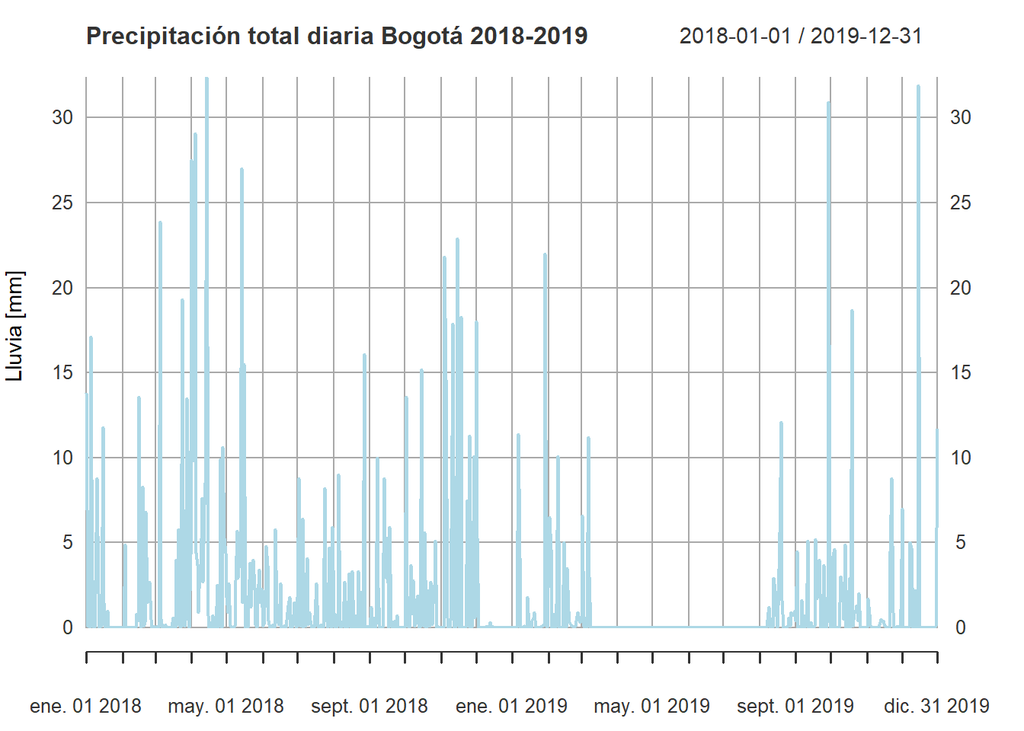

```r
# Plot xts Precipitación Bogotá
plot(BOG_rain_2018_2019,
     main='Precipitación total diaria Bogotá 2018-2019',
     xlab='Tiempo / Día', ylab='Lluvia [mm]',
     col="lightblue")
```

De la anterior gráfica se nota claramente, que aunque anteriormente no se encontraron datos faltantes / NA en el conjunto de datos seleccionados para la precipitación es notorio que entre marzo (mes 3) y agosto (mes 8) de 2019 se presentan de seguido registros de lluvia que son cero, aunque es de esperar que no lloverá todos los días del año en Bogotá, tampoco tiene sentido que se presenten cinco meses de sin registros de lluvia; lo anterior permite inferir que el sensor / pluviómetro presentó fallas en dichos meses y esto se confirma al revisar los datos en el *dataframe* que contiene ceros con un formato diferente (`int` 0 vs `dbl` 0.0) en el periodo en mención[^1].

La figura siguiente presenta la tendencia de la temperatura máxima diaria en Medellín y se observa fácilmente que no encuentran datos por fuera del rango de 20 a 33 ºC.

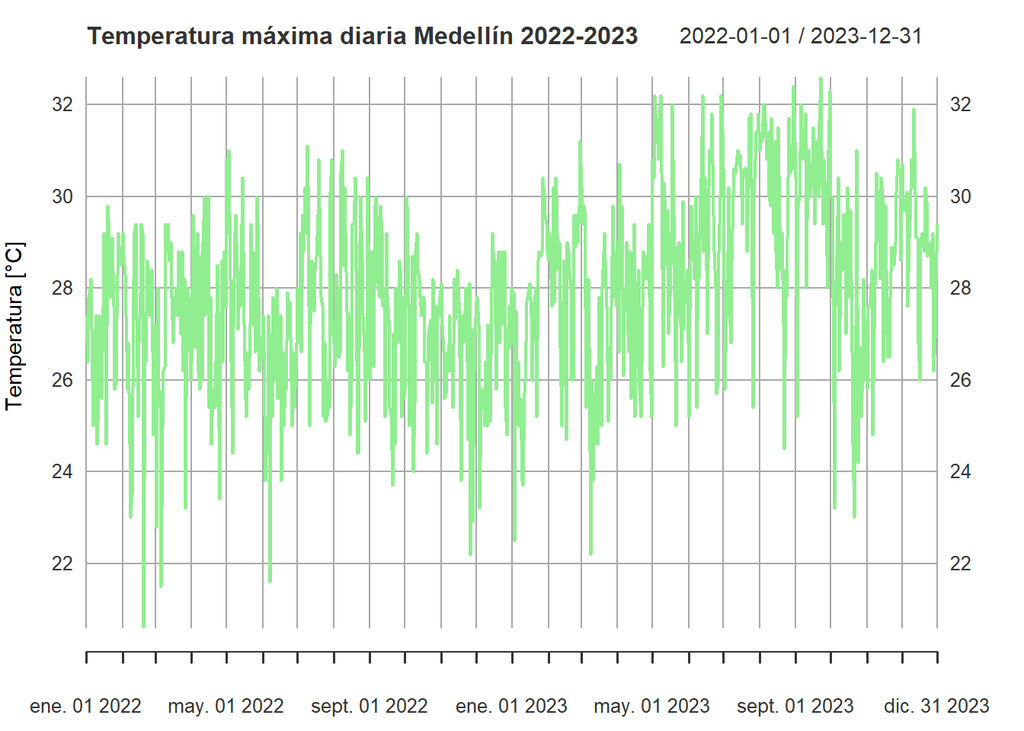

```r
# Plot xts Temperatura Medellín
plot(MED_temp_2022_2023,
     main="Temperatura máxima diaria Medellín 2022-2023",
     xlab='Fecha', ylab='Temperatura [°C]',
     col="lightgreen")
```

Ahora con `lm` obtenemos la tendencia tanto para las series / ts para la precipitación y para la temperatura:

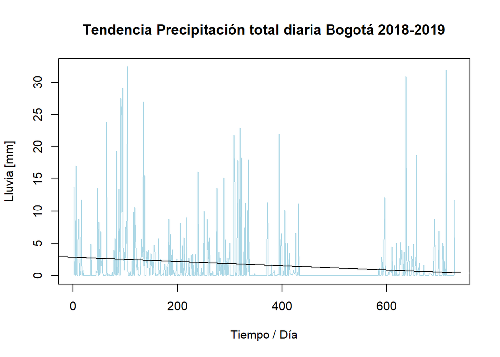

```r
# Tendencia precipitación Bogotá
plot(BOG_rain_2018_2019_ts,
     main='Tendencia Precipitación total diaria Bogotá 2018-2019',
     xlab='Tiempo / Día', ylab='Lluvia [mm]',
     col="lightblue")
abline(reg=lm(BOG_rain_2018_2019_ts~time(BOG_rain_2018_2019_ts)))
```

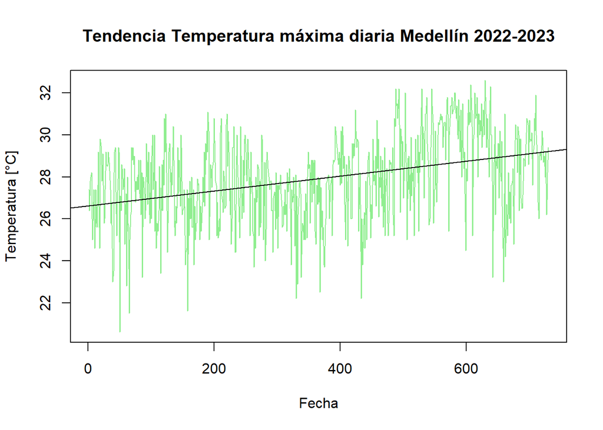

```r
# Tendencia temperatura Medellín
plot(MED_temp_2022_2023_ts,
     main="Tendencia Temperatura máxima diaria Medellín 2022-2023",
     xlab='Fecha', ylab='Temperatura [°C]',
     col="lightgreen")
abline(reg=lm(MED_temp_2022_2023_ts~time(MED_temp_2022_2023_ts)))
```

A continuación se analizan las tendencias mensuales de la precipitación (la lluvia se suma para obtener los mm acumulados por mes) y la temperatura (se promedian los valores mensuales):

```r
# Precipitación total acumulada mensual
BOG_rain_2018_2019_monthly <- apply.monthly(BOG_rain_2018_2019, FUN=sum)
str(BOG_rain_2018_2019_monthly)
```

```
## An xts object on 2018-01-31 / 2019-12-31 containing:
##   Data:    double [24, 1]
##   Columns: BOG
##   Index:   Date [24] (TZ: "UTC")
```

```r
summary(BOG_rain_2018_2019_monthly)
```

```
##      Index                 BOG
##  Min.   :2018-01-31   Min.   :  0.00
##  1st Qu.:2018-07-23   1st Qu.: 23.32
##  Median :2019-01-15   Median : 45.00
##  Mean   :2019-01-14   Mean   : 51.18
##  3rd Qu.:2019-07-07   3rd Qu.: 63.20
##  Max.   :2019-12-31   Max.   :199.70
```

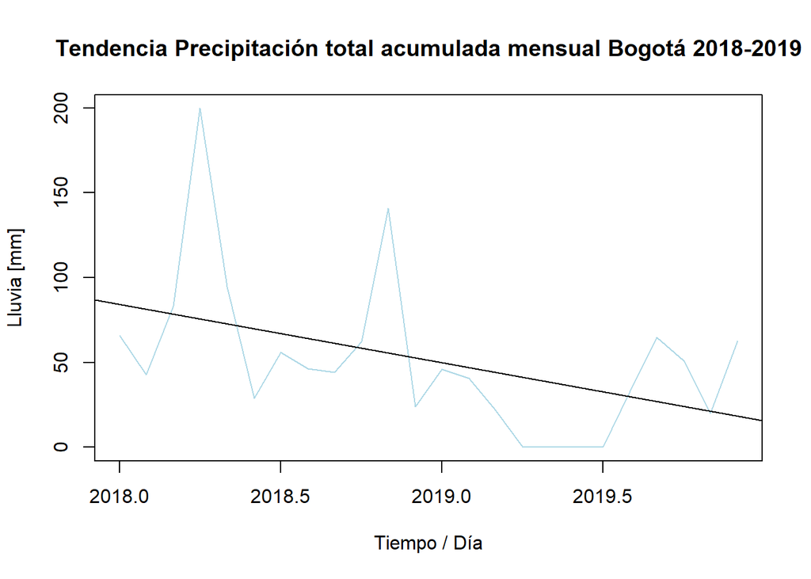

```r
BOG_rain_2018_2019_monthly_ts <- ts(BOG_rain_2018_2019_monthly, start=c(2018, 1), frequency=12)

# Tendencia precipitación acumulada mensual Bogotá
plot(BOG_rain_2018_2019_monthly_ts,
     main='Tendencia Precipitación total acumulada mensual Bogotá 2018-2019',
     xlab='Tiempo / Día', ylab='Lluvia [mm]',
     col="lightblue")
abline(reg=lm(BOG_rain_2018_2019_monthly_ts~time(BOG_rain_2018_2019_monthly_ts)))
```

En la figura anterior se confirma que con los datos de abril, mayo, junio y julio de 2019 en el *dataset* se obtienen precipitaciones mensuales de cero milímetros, por lo que dichos meses se asumen como no válidos debido a fallas en el equipo de medición.

En la figura siguiente se presenta la tendencia de la temperatura máxima promedio mensual que presenta como era de esperar una línea creciente de aproximadamente de 26.5 a 29 ºC.

```r
# Temperatura máxima promedio mensual
MED_temp_2022_2023_monthly <- apply.monthly(MED_temp_2022_2023, FUN=mean)
```

[output not shown]

```r
str(MED_temp_2022_2023_monthly)
```

```
## An xts object on 2022-01-31 / 2023-12-31 containing:
##   Data:    double [24, 1]
##   Columns: MED
##   Index:   Date [24] (TZ: "UTC")
```

```r
summary(MED_temp_2022_2023_monthly)
```

```
##      Index                 MED
##  Min.   :2022-01-31   Min.   :26.04
##  1st Qu.:2022-07-23   1st Qu.:27.14
##  Median :2023-01-15   Median :27.57
##  Mean   :2023-01-14   Mean   :27.92
##  3rd Qu.:2023-07-07   3rd Qu.:28.67
##  Max.   :2023-12-31   Max.   :30.39
```

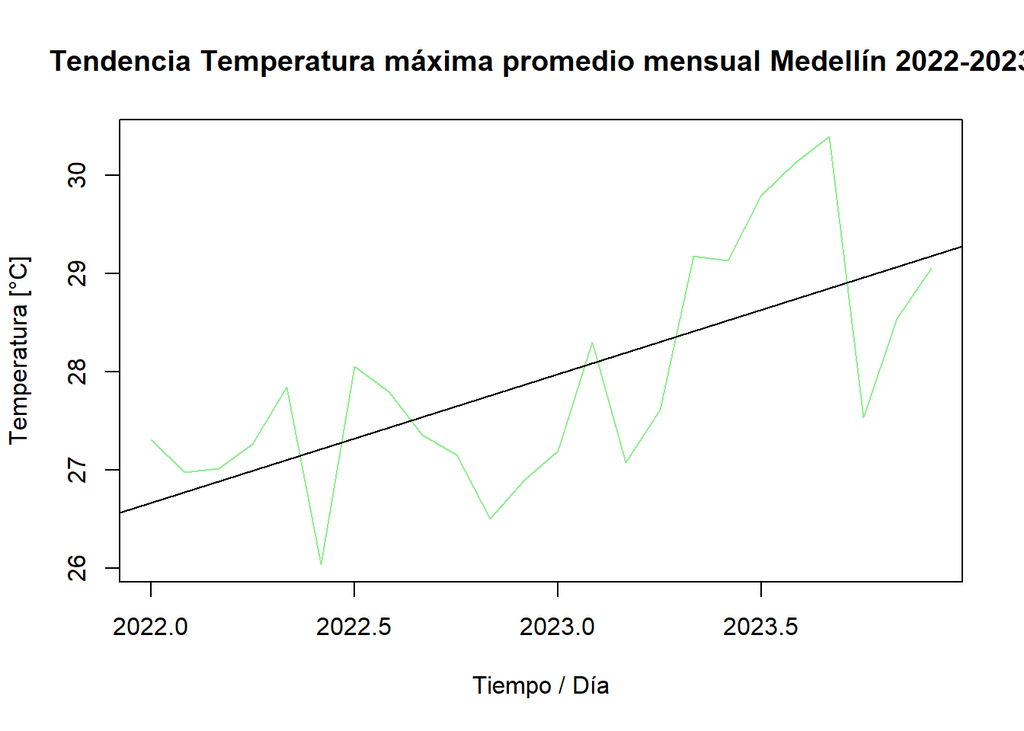

```r
MED_temp_2022_2023_monthly_ts <- ts(MED_temp_2022_2023_monthly, start=c(2022, 1), frequency=12)


# Tendencia temperatura promedio mensual Medellín
plot(MED_temp_2022_2023_monthly_ts,
     main="Tendencia Temperatura máxima promedio mensual Medellín 2022-2023",
     xlab='Tiempo / Día', ylab='Temperatura [°C]',
     col="lightgreen")
abline(reg=lm(MED_temp_2022_2023_monthly_ts~time(MED_temp_2022_2023_monthly_ts)))
```

A continuación obtenemos el ciclo mensual para cada una de las variables estudiadas en las ciudades seleccionadas y se grafica con `aggregate`.

```r
# Ciclo lluvia Bogotá
cycle(BOG_rain_2018_2019_monthly_ts)
```

```
##      Jan Feb Mar Apr May Jun Jul Aug Sep Oct Nov Dec
## 2018   1   2   3   4   5   6   7   8   9  10  11  12
## 2019   1   2   3   4   5   6   7   8   9  10  11  12
```

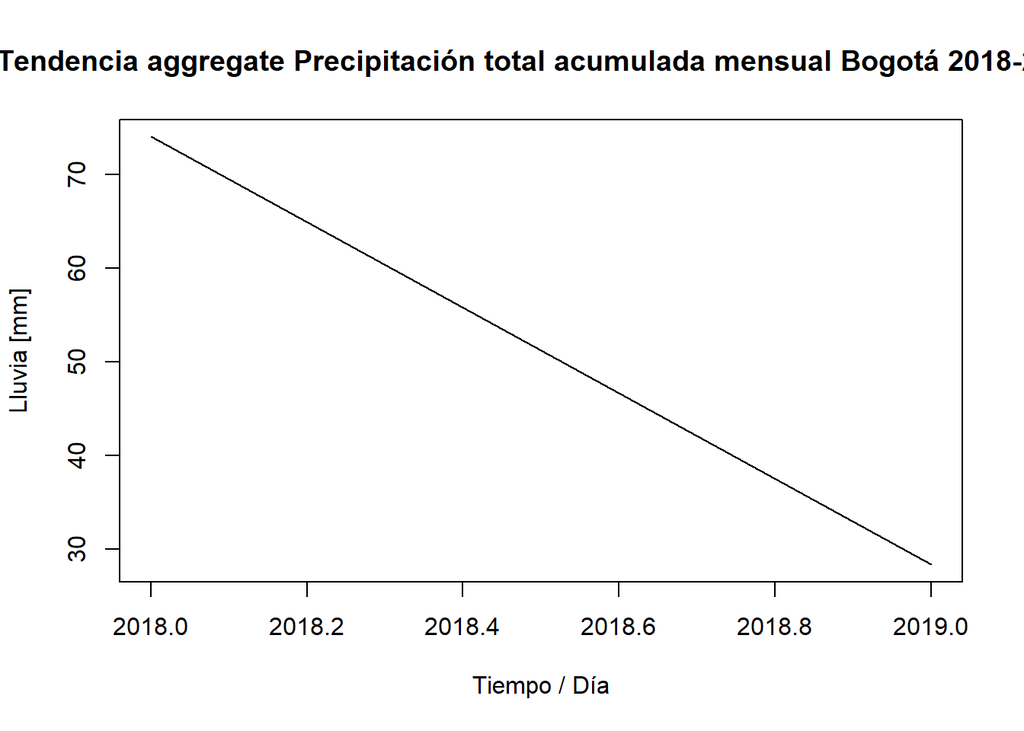

```r
plot(aggregate(BOG_rain_2018_2019_monthly_ts, FUN=mean),
     main='Tendencia aggregate Precipitación total acumulada mensual Bogotá 2018-2019',
     xlab='Tiempo / Día', ylab='Lluvia [mm]')
```

Tanto en la gráfica anterior, como en la siguiente, en ambos casos se obtienen las mismas tendencias para la precipitación y la temperatura que las encontradas con `abline` y la regresión lineal con `lm`.

```r
# Ciclo temperatura Medellín
cycle(MED_temp_2022_2023_monthly_ts)
```

```
##      Jan Feb Mar Apr May Jun Jul Aug Sep Oct Nov Dec
## 2022   1   2   3   4   5   6   7   8   9  10  11  12
## 2023   1   2   3   4   5   6   7   8   9  10  11  12
```

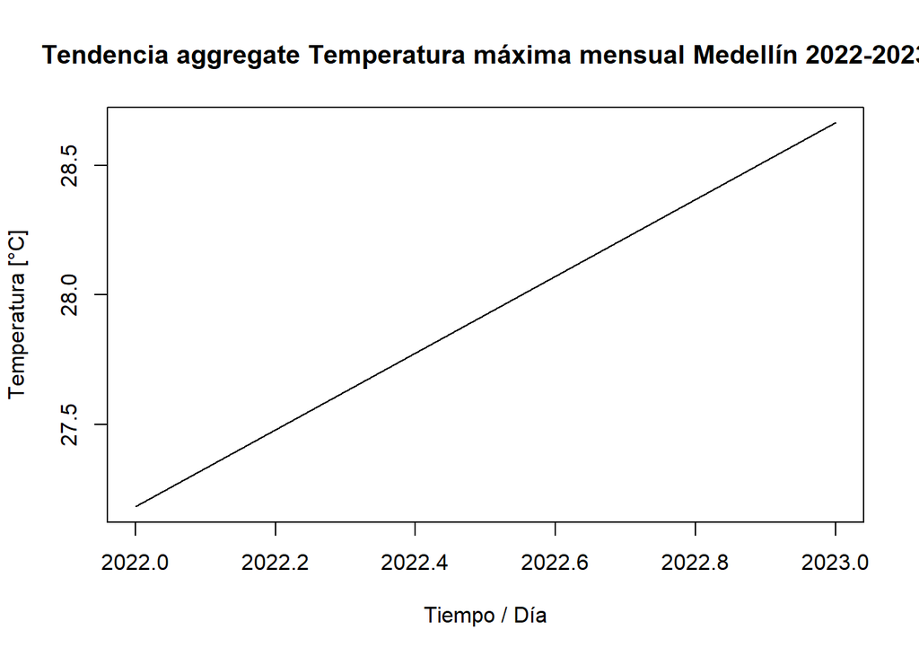

```r
plot(aggregate(MED_temp_2022_2023_monthly_ts, FUN=mean),
     main="Tendencia aggregate Temperatura máxima mensual Medellín 2022-2023",
     xlab='Tiempo / Día', ylab='Temperatura [°C]',)
```

Ahora se presenta la dispersión / comportamiento mensual por medio de boxplots para tanto de las precipitaciones en Bogotá, así como para las temperaturas en Medellín:

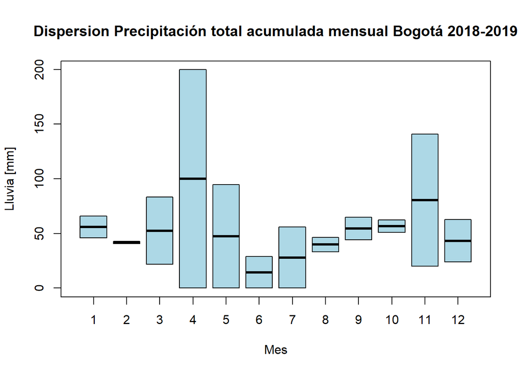

```r
# Boxpplot lluvia mensual Bogotá
boxplot(BOG_rain_2018_2019_monthly_ts~cycle(BOG_rain_2018_2019_monthly_ts),
        main="Dispersion Precipitación total acumulada mensual Bogotá 2018-2019",
     xlab='Mes', ylab='Lluvia [mm]',
     col="lightblue")
```

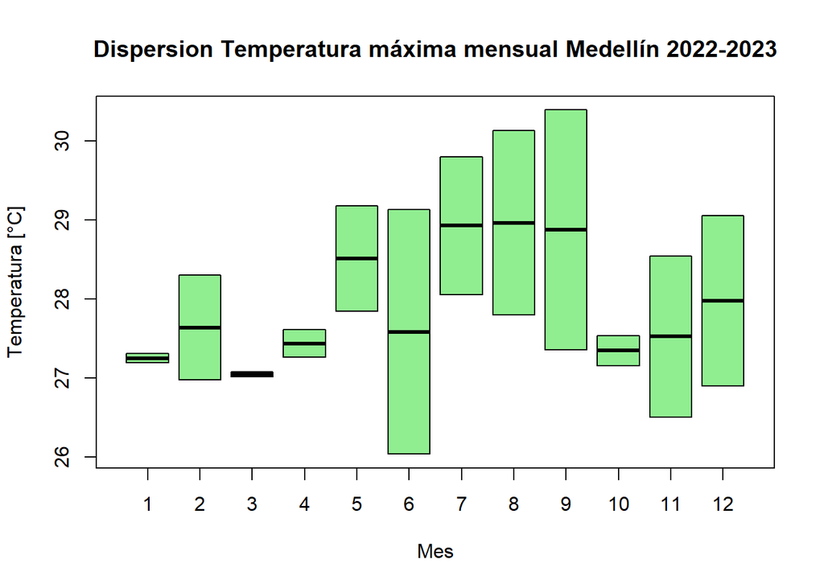

```r
# Boxplot temperatura mensual Medellín
boxplot(MED_temp_2022_2023_monthly_ts~cycle(MED_temp_2022_2023_monthly_ts),
        main="Dispersion Temperatura máxima mensual Medellín 2022-2023",
        xlab='Mes', ylab='Temperatura [°C]',
     col="lightgreen")
```

Tal como se refiere en los materiales de la unidad, se procede a probar la función logaritmo[^2] para graficar nuevamente los datos de temperatura y evidenciar si se obtiene alguna mejora en la visualización de las series diarias y mensuales.

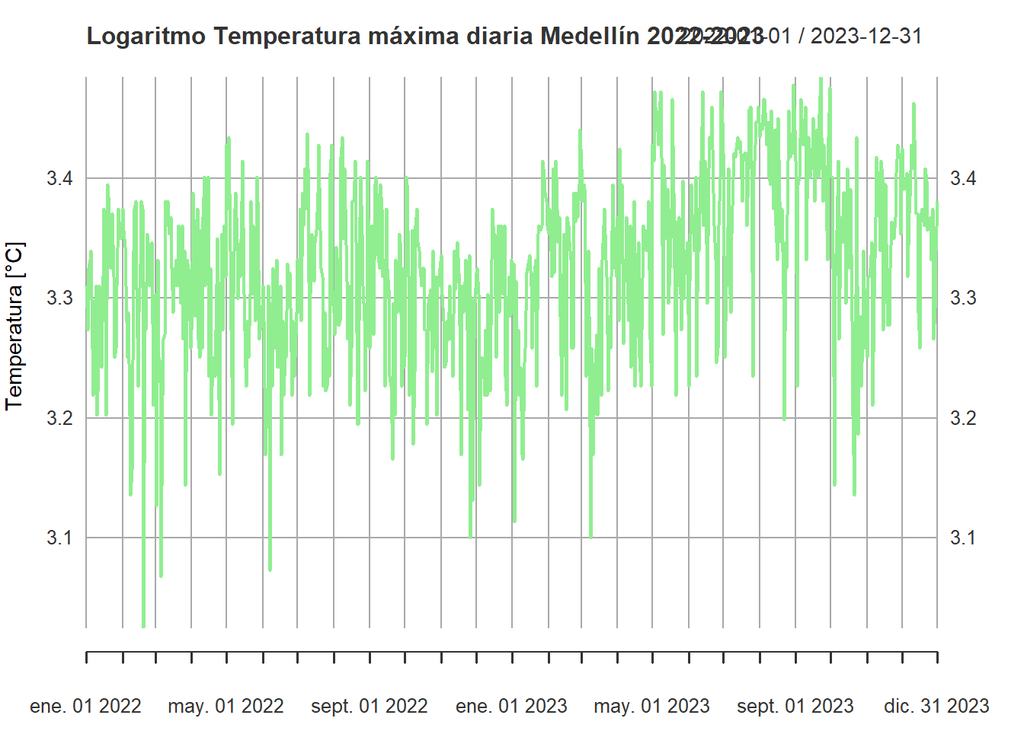

```r
# Logaritmo temperatura Medellín
plot(log(MED_temp_2022_2023),
     main="Logaritmo Temperatura máxima diaria Medellín 2022-2023",
     xlab='Fecha', ylab='Temperatura [°C]',
     col="lightgreen")
```

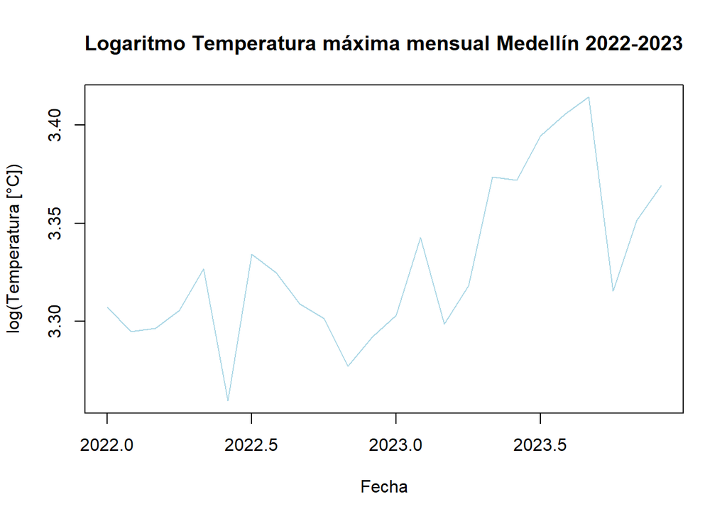

```r
# Logaritmo temperatura mensual Medellín
plot(log(MED_temp_2022_2023_monthly_ts),
     main='Logaritmo Temperatura máxima mensual Medellín 2022-2023',
     xlab='Fecha', ylab='log(Temperatura [°C])',
     col="lightblue")
```

## Modelo Holt-Winters

Ahora, aplicamos el modelo Holt-Winters para la serie mensual de temperatura[^3] en Medellín obtenida en el presente capítulo.

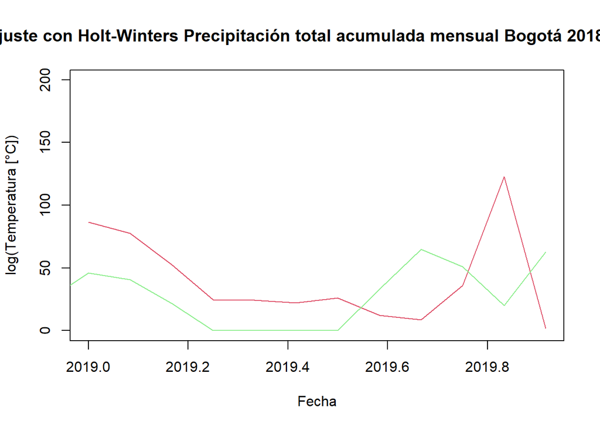

```r
# Holt Winters log temperatura mensual Medellín
BOG_rain_2018_2019_monthly_HW <- HoltWinters(BOG_rain_2018_2019_monthly_ts,
                                             seasonal = "additive")

plot(BOG_rain_2018_2019_monthly_HW,
     main='Ajuste con Holt-Winters Precipitación total acumulada mensual Bogotá 2018-2019',
     xlab='Fecha', ylab='log(Temperatura [°C])',
     col="lightgreen")
```

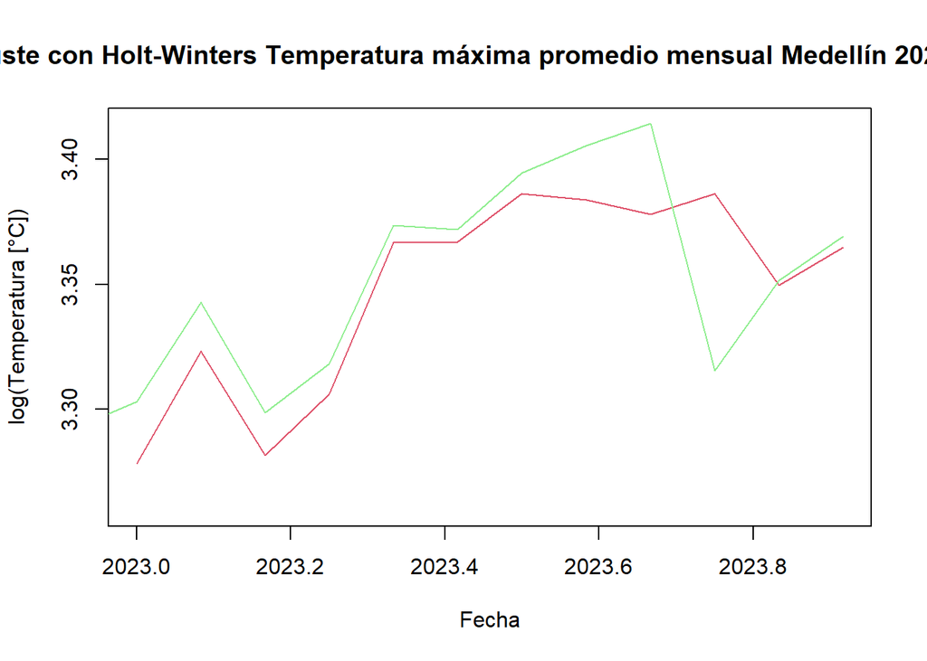

```r
# Holt Winters log temperatura mensual Medellín
MED_temp_2022_2023_monthly_HW <- HoltWinters(log(MED_temp_2022_2023_monthly_ts),
                                             seasonal = "additive")

plot(MED_temp_2022_2023_monthly_HW,
     main='Ajuste con Holt-Winters Temperatura máxima promedio mensual Medellín 2022-2023',
     xlab='Fecha', ylab='log(Temperatura [°C])',
     col="lightgreen")
```

A continuación se presentan la descomposición para el modelo obtenido anteriormente:

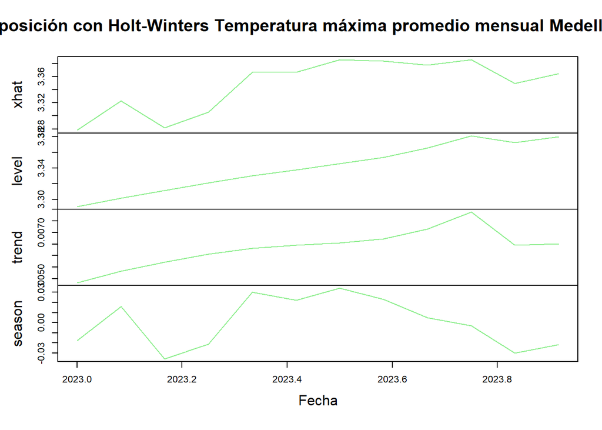

```r
# Descomposición Holt Winters log temperatura Medellín
plot(fitted(MED_temp_2022_2023_monthly_HW),
     main='Descomposición con Holt-Winters Temperatura máxima promedio mensual Medellín 2022-2023',
     xlab='Fecha', ylab='log(Temperatura [°C])',
     col="lightgreen")
```

## Predicciones iniciales

Ahora que contamos con los modelos Holt Winters aplicados a la series mensuales de temperatura en Medellín, se procede a realizar unas predicciones iniciales para seis meses.

```r
# Predicción Holt Winters log temperatura Medellín
MED_temp_2022_2023_monthly_Pred <- predict(MED_temp_2022_2023_monthly_HW, 6, prediction.interval = TRUE)
MED_temp_2022_2023_monthly_Pred
```

```
##               fit      upr      lwr
## Jan 2024 3.378123 3.430217 3.326029
## Feb 2024 3.418200 3.471906 3.364494
## Mar 2024 3.372686 3.428214 3.317158
## Apr 2024 3.393397 3.450955 3.335838
## May 2024 3.451220 3.511015 3.391425
## Jun 2024 3.449746 3.511980 3.387513
```

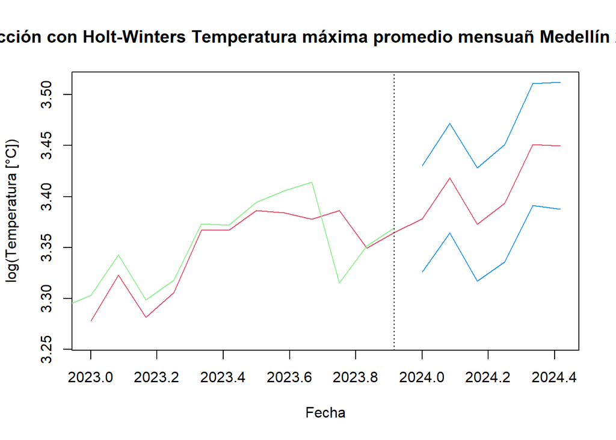

```r
# Gráfico Predicción Holt Winters log temperatura Medellín
plot(MED_temp_2022_2023_monthly_HW, MED_temp_2022_2023_monthly_Pred,
     main='Predicción con Holt-Winters Temperatura máxima promedio mensuañ Medellín 2022-2024',
     xlab='Fecha', ylab='log(Temperatura [°C])',
     col=c("lightgreen", "green"))
```